# 1.2. Measures of Dipsersion (Spread)

**Que:** Consider the following two data sets:

```
set1 = [1, 2, 3, 4, 5, 6, 6, 7, 8, 9, 10, 11]

set2 = [4, 5, 5, 5, 6, 6, 6, 6, 7, 7, 7, 8]
```

Compute the mean, median, and mode of each of the two data sets.

```python
import numpy as np
from scipy import stats

set1 = [1, 2, 3, 4, 5, 6, 6, 7, 8, 9, 10, 11]
set2 = [4, 5, 5, 5, 6, 6, 6, 6, 7, 7, 7, 8]

#computing mean
mean1 = np.mean(set1)
mean2 = np.mean(set2)

#computing median
median1 = np.median(set1)
median2 = np.median(set2)

#computing mode
mode1 = stats.mode(set1)[0][0]
mode2 = stats.mode(set2)[0][0]

print('Set 1 - Mean:',mean1, ', Median:',median1, ', Mode :',mode1)
print('Set 2 - Mean:',mean2, ', Median:',median2, ', Mode :',mode2)
```

```
Set 1 - Mean: 6.0 , Median: 6.0 , Mode : 6
Set 2 - Mean: 6.0 , Median: 6.0 , Mode : 6
```

As you see from your results, the two data sets have the same mean, the same median, and the same mode, all equal to 6. The two data sets also happen to have the same number of observations, $n = 12$. But the two data sets are different. What is the main difference between them?

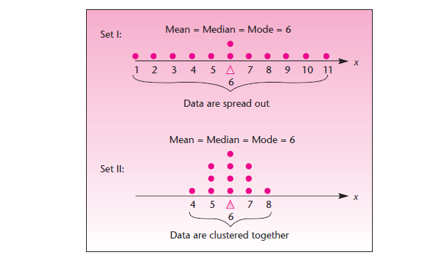

The two data sets have the same central tendency (as measured by any of the three measures of centrality), but they have a different variability. In particular, we see that data set I have more variation than data set II. The values in set I are more spread out: they lie farther away from their mean than do those of set II.

Thus we see that the measures of central tendency are inadequate to give us a complete idea of the distribution. They must be supported and supplemented by some other measures. One such measure is Dispersion also called measure of variablility or simply spread of the data.

**Measure of Dispersion (Spread):** Literal meaning of dispersion is ‘scatteredness’. Dispersion is the variation in the data, and measures the inconsistencies in the value of variables in the data. Dispersion actually provides an idea about the spread rather than central values.

## Range

The range is the difference between the maximum and minimum value of the data set.

```python
#Consider this data of game points

pnts = [37, 56, 43, 59, 63, 79, 34, 41, 64, 43, 92, 60, 77, 27, 81]
```

```python
#Find the range

rng = max(pnts) - min(pnts)
print("Range:",rng)
```

```
Range: 65
```

## Interquartile Range

It is a measure of dispersion based on the upper quartile $Q_3$ and the lower quartile $Q_1$ i.e.,

$$ Interquartile \, Range = Q_3 - Q_1 $$

So what are these values $Q_3$ and $Q_1$ ? Lets see,

### Quantiles:

These are simply identical fragments (subdivisions) of the data.

Quantiles covers:

- quartiles
- deciles
- percentiles and so on.

These measures are calculated after arranging the data in ascending order.

### Quartile:

The values which divide the given series of given data into four equal parts, when arranged in ascending or descending order are called quartiles. There are 3 such points denoted by $Q_1, Q_2, Q_3$ such that $Q_1 \le Q_2 \le Q_3$. Thus each quartile act as a marker of one-fourth of the data.

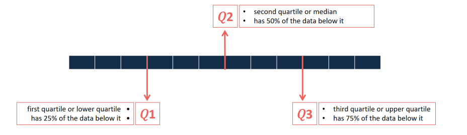

$Q_1$ known as the first quartile or lower quartile is the value which has 25% of the items of the distribution below it. $Q_2$, the second quartile has 50% of the observations below it and *coincides with the median*. $Q_3$, known as the third quartile or upper quartile has 75% of the observations below it.

### Percentiles:

Percentiles are the values which divide the series into 100 equal parts, when arranged in ascending or descending order. There are 99 points denoted by $P_1,P_2,….,P_{99}$ such that $P_1,\le P_2 \le ….,\le P_{99}$. In the case of percentiles $P_{50}$ coincides with the median as the number of data points below the median is about 50 percent of the data.

Quartiles are often also expressed as percentiles.The first quartile is 25 percent of the data, the second quartile is 50 percent of the data, the third quartile is 75 percent of the data. The second quartile is also known as the median or 50th percentile or 5th decile.

Observe that for a data set:

- $P_{ 25} = Q_1$
- $P_{ 50} = Q_2$
- $P_{ 75} = Q_3$

```python
#Consider this data of game points

pnts = [35,56,43,59,63,79,35,41,64,43,93,60,77,24,82]
```

```python
# finding quratiles

from statistics import quantiles

Q = quantiles(pnts, n = 4, method = 'inclusive')

print(Q)
```

```
[42.0, 59.0, 70.5]
```

```python
# find quartiles via percentile

from numpy import percentile

quartiles = percentile(pnts, [25, 50, 75])
# print(quartiles)

for i,j in zip(range(1,4),quartiles):
    print("\nQ",i,'=',j)
```

```
Q 1 = 42.0

Q 2 = 59.0

Q 3 = 70.5
```

```python
#computing IQR using 3rd and 1st quartile

IQR = quartiles[2] - quartiles[0]  #IQR = Q3 - Q1
print('Interquartile Range =', IQR)
```

```
Interquartile Range = 28.5
```

**The range and the interquartile range are measures of the dispersion of a set of observations, the interquartile range being more resistant to extreme observations.**